# IE582-HW4

H.Pınar Yıldırım

27 12 2021

```r
getwd()
```

```
## [1] "C:/Users/asus_pinar/Desktop/files"
```

```r
setwd('C:/Users/asus_pinar/desktop/files')
getwd()
```

```
## [1] "C:/Users/asus_pinar/desktop/files"
```

```r
#library(genlasso)
library(data.table)
library(rpart)
library(repr)
require(scatterplot3d)
require(FNN)
library(ggplot2)
require(randomForest)
require(TunePareto)
options(scipen=999)
options(repr.plot.width=15, repr.plot.height=8)
```

### Function Definitions

#### Nearest Neighbor Classification with Cross-Validation

Returns class predictions given test indices and k.

```r
nn_classify_cv=function(dist_matrix,train_class,test_indices,k){

  test_distances_to_train=as.matrix(dist_matrix[test_indices,])
  test_distances_to_train=test_distances_to_train[,-test_indices]
  trainclass=train_class[-test_indices]
  #print(str(test_distances_to_train))
  ordered_indices=apply(test_distances_to_train,1,order)
  if(k==1){
    nearest_class=(trainclass[as.numeric(ordered_indices[1,])])
    nearest_class=data.table(id=test_indices,nearest_class)
  } else {
    nearest_class=apply(ordered_indices[1:k,],2,function(x) {trainclass[x]})
    nearest_class=as.data.table(nearest_class)
    nearest_class=data.table(id=test_indices,t(nearest_class))
  }

  long_nn_class=melt(nearest_class,'id')

  class_counts=long_nn_class[,.N,list(id,value)]
  class_counts[,predicted_prob:=N/k]
  wide_class_prob_predictions=dcast(class_counts,id~value,value.var='predicted_prob')
  wide_class_prob_predictions[is.na(wide_class_prob_predictions)]=0
  class_predictions=class_counts[,list(predicted=value[which.max(N)]),by=list(id)]


  return(list(prediction=class_predictions,prob_estimates=wide_class_prob_predictions))

}
```

#### Random Forest for Classification with Cross-Validation

Returns class predictions given test indices and ntree.

```r
RF_classify_cv=function(data_df, test_indices, ntr){

  data_df = long_repr
  test_df=data_df[test_indices,]
  train_df=data_df[-test_indices,]

  test_features = test_df[,-c("BagID", "BagLabel")]
  test_target = test_df[,"BagLabel"]
  test_df = test_df[,-("BagID")]

  train_features = train_df[,-c("BagID", "BagLabel")]
  train_target = train_df[,"BagLabel"]
  train_df = train_df[,-("BagID")]


  fit_to_repr_rf=randomForest(train_df[,-c('BagLabel'),with=F],
                         as.factor(train_df$BagLabel),
                         importance=TRUE,
                         ntree=ntr)

  predicted=predict(fit_to_repr_rf,test_df)

  return(predicted)

}
```

### Reading the Dataset

```r
musk_data = read.csv("Musk1.csv")
musk_data = as.data.table(musk_data)

colnames(musk_data)[1]=c("BagLabel")
colnames(musk_data)[2]=c("BagID")

head(musk_data)
```

```
##    BagLabel BagID X42 X.198 X.109 X.75 X.117 X11 X23 X.88 X.28 X.27 X.232 X.212
## 1:        1     1  42  -191  -142  -65  -117  55  49 -170  -45    5  -325  -115
## 2:        1     1  42  -191  -142  -75  -117  11  49 -161  -45  -28  -278  -115
## 3:        1     1  42  -198  -110  -65  -117  55  23  -95  -28    5  -301  -212
## 4:        1     2  42  -198  -102  -75  -117  10  24  -87  -28  -28  -233  -212
## 5:        1     2  42  -191  -142  -65  -117  55  49 -170  -45    6  -324  -114
## 6:        1     2  42  -190  -142  -75  -117  12  49 -161  -45  -29  -277  -114
##    X.66 X.286 X.287 X.300 X.57 X.75.1 X.192 X.184 X.66.1 X.18 X.50 X111 X110
## 1: -107  -281  -257  -303   54   -154  -101   -47    -31  -28    1  191   72
## 2:  -67  -274  -285  -303   53   -154  -100  -183    -31  -28    1  110  110
## 3: -107  -280  -284  -301  -56    -74  -192   -46    -66  -19  -50  191   73
## 4:  -67  -286  -286  -299  -57    -74  -191  -182    -66  -18  -50  109  111
## 5: -106  -280  -257  -302   54   -153  -100   -47    -30  -28    1  190   73
## 6:  -68  -274  -285  -302   54   -153  -100  -182    -31  -28    0  108  110
##    X18 X.18.1 X.127 X25 X63 X.117.1 X.114 X.47 X9 X.135 X26 X.175 X73 X.143 X71
```

[output cut: 76 more lines]

```r
tail(musk_data)
```

```
##    BagLabel BagID X42 X.198 X.109 X.75 X.117 X11  X23 X.88 X.28 X.27 X.232
## 1:        0    92  52  -123   -24  -43  -117 -82 -163   60 -234  -13  -106
## 2:        0    92  49  -199  -161   29   -95 -86  -48    2  112  -79   -47
## 3:        0    92  38  -123  -139   30  -117 -88  214  -13  -74 -129   -40
## 4:        0    92  43  -102   -20 -101  -116 200 -166   66 -222  -49  -120
## 5:        0    92  39   -58    27   31  -117 -92   85   21  -73  -68   -47
## 6:        0    92  52  -121   -24 -104  -116 195 -162   76 -226  -56  -138
##    X.212 X.66 X.286 X.287 X.300 X.57 X.75.1 X.192 X.184 X.66.1 X.18 X.50 X111
## 1:  -105  -93   -83   -88  -282 -221    -45   -31   -15   -174 -184 -177  289
## 2:   -43  -30  -134   -89  -244   96    -57     5   -58    -78   68   15  -58
## 3:   -26  -59  -109  -106  -271 -112    -91   -18   -19    -52  104   -6  -60
## 4:   -80  -48   -82   -98   -99 -216    -22   -59    -2   -112 -183 -201  -59
## 5:   -27  -23  -112   -98  -291  -90    -63   -64   -65    -46  -17   -2  -67
## 6:   -69  -53   -83  -106   -94 -221    -34   -63     7   -105 -183 -196  -46
##    X110  X18 X.18.1 X.127  X25  X63 X.117.1 X.114 X.47   X9 X.135 X26 X.175
```

[output cut: 76 more lines]

```r
summary(musk_data)
```

```
##     BagLabel          BagID            X42             X.198
##  Min.   :0.0000   Min.   : 1.00   Min.   : -9.00   Min.   :-199
##  1st Qu.:0.0000   1st Qu.:29.00   1st Qu.: 31.00   1st Qu.:-193
##  Median :0.0000   Median :57.00   Median : 42.00   Median :-144
##  Mean   :0.4337   Mean   :52.49   Mean   : 38.72   Mean   :-120
##  3rd Qu.:1.0000   3rd Qu.:81.00   3rd Qu.: 50.00   3rd Qu.:-101
##  Max.   :1.0000   Max.   :92.00   Max.   :130.00   Max.   :  98
##      X.109              X.75             X.117             X11
##  Min.   :-166.00   Min.   :-115.00   Min.   :-117.0   Min.   :-184.000
##  1st Qu.:-144.00   1st Qu.: -52.50   1st Qu.:-117.0   1st Qu.: -89.000
##  Median :-108.00   Median :  28.00   Median :-117.0   Median :  11.000
##  Mean   : -79.18   Mean   :  16.09   Mean   :-112.3   Mean   :  -9.804
##  3rd Qu.: -21.00   3rd Qu.:  38.00   3rd Qu.:-117.0   3rd Qu.:  70.500
##  Max.   :  83.00   Max.   : 157.00   Max.   : 238.0   Max.   : 200.000
##       X23               X.88               X.28              X.27
##  Min.   :-170.00   Min.   :-231.000   Min.   :-242.00   Min.   :-284.00
##  1st Qu.:-159.00   1st Qu.:  -9.000   1st Qu.:-215.00   1st Qu.:-118.50
##  Median :  41.00   Median :  18.000   Median : -41.00   Median : -74.00
##  Mean   : -16.71   Mean   :   7.964   Mean   : -91.18   Mean   : -76.18
##  3rd Qu.:  51.00   3rd Qu.:  57.000   3rd Qu.: -30.00   3rd Qu.: -28.00
##  Max.   : 214.00   Max.   : 188.000   Max.   : 135.00   Max.   : 218.00
##      X.232             X.212              X.66             X.286
##  Min.   :-327.00   Min.   :-326.00   Min.   :-302.00   Min.   :-348.0
##  1st Qu.:-112.00   1st Qu.:-103.50   1st Qu.: -86.00   1st Qu.:-124.5
##  Median : -57.00   Median : -69.00   Median : -62.00   Median : -97.0
##  Mean   : -94.05   Mean   : -69.79   Mean   : -71.64   Mean   :-114.3
##  3rd Qu.: -46.00   3rd Qu.: -29.00   3rd Qu.: -42.00   3rd Qu.: -82.0
##  Max.   : 104.00   Max.   : 196.00   Max.   : 117.00   Max.   :  72.0
##      X.287            X.300             X.57             X.75.1
##  Min.   :-292.0   Min.   :-318.0   Min.   :-225.00   Min.   :-312.00
##  1st Qu.:-109.0   1st Qu.:-296.0   1st Qu.:-168.50   1st Qu.: -88.00
##  Median : -94.0   Median :-285.0   Median :  28.00   Median : -69.00
##  Mean   :-106.3   Mean   :-265.0   Mean   : -41.28   Mean   : -71.45
##  3rd Qu.: -77.0   3rd Qu.:-266.5   3rd Qu.:  50.00   3rd Qu.: -46.50
##  Max.   :  77.0   Max.   :  13.0   Max.   : 125.00   Max.   : 139.00
##      X.192             X.184             X.66.1             X.18
##  Min.   :-291.00   Min.   :-243.00   Min.   :-298.00   Min.   :-187.00
##  1st Qu.: -73.00   1st Qu.: -61.00   1st Qu.:-106.50   1st Qu.:-179.00
##  Median : -31.00   Median : -39.00   Median : -67.00   Median : -22.00
##  Mean   : -38.37   Mean   : -48.07   Mean   : -73.23   Mean   : -63.67
```

[output cut: 239 more lines]

```
##  Max.   : 161.00   Max.   : 113.00   Max.   : 141.0   Max.   :  72.0
##      X.129           X.120.2            X.38.1             X30
##  Min.   :-217.0   Min.   :-135.00   Min.   :-126.00   Min.   :-78.00
##  1st Qu.:-208.0   1st Qu.: -90.50   1st Qu.: -39.50   1st Qu.: 34.00
##  Median :-190.0   Median : -15.00   Median :  32.00   Median : 86.00
##  Mean   :-108.2   Mean   : -25.03   Mean   :  37.59   Mean   : 79.86
##  3rd Qu.:  30.0   3rd Qu.:  22.00   3rd Qu.: 128.00   3rd Qu.:119.00
##  Max.   : 173.0   Max.   : 185.00   Max.   : 253.00   Max.   :291.00
##      X48.1            X.37.2             X6.1             X30.1
##  Min.   : 35.00   Min.   :-132.00   Min.   :-258.00   Min.   :-72.00
##  1st Qu.: 54.00   1st Qu.: -42.50   1st Qu.: -28.00   1st Qu.:-12.00
##  Median : 69.00   Median : -36.00   Median : -12.00   Median : 35.00
##  Mean   : 85.44   Mean   : -34.12   Mean   : -26.31   Mean   : 33.72
##  3rd Qu.: 99.00   3rd Qu.: -28.00   3rd Qu.:   7.00   3rd Qu.: 74.00
##  Max.   :302.00   Max.   :  24.00   Max.   :  82.00   Max.   :235.00
```

The first column is a binary column that shows if the bag is musk or non-musk. Instances are already clustered into bags. All instances in a bag assumed to have the same label as the bag. Second column shows the bag ID’s. There are 92 bags of which 47 are labeled as 1 and 45 as 0. Number of observations in each bag differs with a minimum of 2 and a maximum of 40.

Bags represent 92 molecules which are classified as musk or non-musk by human experts. Due to the rotation of bonds a molecule could have different shapes, conformations. 475 observations shows different conformations of molecules represented with the features in remaining 166 columns. All features are numeric with different ranges

The goal is to learn to predict whether a new molecule is a musk or a non-musk.

```r
c(unique(musk_data[,"BagID"]))
```

```
## $BagID
##  [1]  1  2  3  4  5  6  7  8  9 10 11 12 13 14 15 16 17 18 19 20 21 22 23 24 25
## [26] 26 27 28 29 30 31 32 33 34 35 36 37 38 39 40 41 42 43 44 45 46 47 48 49 50
## [51] 51 52 53 54 55 56 57 58 59 60 61 62 63 64 65 66 67 68 69 70 71 72 73 74 75
## [76] 76 77 78 79 80 81 82 83 84 85 86 87 88 89 90 91 92
```

```r
print("1 Labeled Rows Count ")
```

```
## [1] "1 Labeled Rows Count "
```

```r
nrow(musk_data[BagLabel==1,])
```

```
## [1] 206
```

```r
print("0 Labeled Rows Count ")
```

```
## [1] "0 Labeled Rows Count "
```

```r
nrow(musk_data[BagLabel==0,])
```

```
## [1] 269
```

```r
print("1 Labeled Bags Count ")
```

```
## [1] "1 Labeled Bags Count "
```

```r
sum(musk_data[, list(Labs=mean(BagLabel)), BagID]$Labs==1)
```

```
## [1] 47
```

```r
print("0 Labeled Rows Count ")
```

```
## [1] "0 Labeled Rows Count "
```

```r
sum(musk_data[, list(Labs=mean(BagLabel)), BagID]$Labs==0)
```

```
## [1] 45
```

```r
print("NA variables")
```

```
## [1] "NA variables"
```

```r
sum(is.na(musk_data))
```

```
## [1] 0
```

### Observing Bags

```r
#create bagged df
bagged_df = data.table(unique(musk_data[,"BagID"])) #bagID
bagged_df[,nof_instances:=as.numeric(table(musk_data$BagID))]   #number of instances in each bag
bagged_df[,BagLabel:=musk_data[, list(Labs=mean(BagLabel)), BagID]$Labs]  #labels of each bag
(bagged_df)
```

```
##     BagID nof_instances BagLabel
##  1:     1             3        1
##  2:     2             4        1
##  3:     3             2        1
##  4:     4             3        1
##  5:     5             4        1
##  6:     6             2        1
##  7:     7             2        1
##  8:     8             2        1
##  9:     9             5        1
## 10:    10             6        1
## 11:    11             5        1
## 12:    12             8        1
## 13:    13             4        1
## 14:    14             2        1
```

[output cut: 79 more lines]

### Descriptive Analysis

```r
#Renaming features X1 to X166
feature_list=c()
for( i in 1:166){
  feature_list = append(feature_list,(paste("X", i, sep="")))
}
colnames(musk_data)[3:168] = feature_list
#head(musk_data,5)

#add observation indices
musk_data[,index:=1:.N]
```

#### Feature Plots

```r
## PLOTTING FEATURES
musk_melted=(melt(musk_data[,-c(2)] ,  id.vars = c('index','BagLabel'), variable.name = 'feature'))
musk_melted=musk_melted[order(musk_melted$index)]

for( ft in colnames(musk_data)){
  print(ggplot(data = musk_melted[feature==ft])+geom_point(aes(y=value,
                                                               x=index,
                                                               col=as.factor(musk_melted[feature==ft]$BagLabel))))
}
```

[output not shown]

#### Visualization with MDS 2D (on instance level)

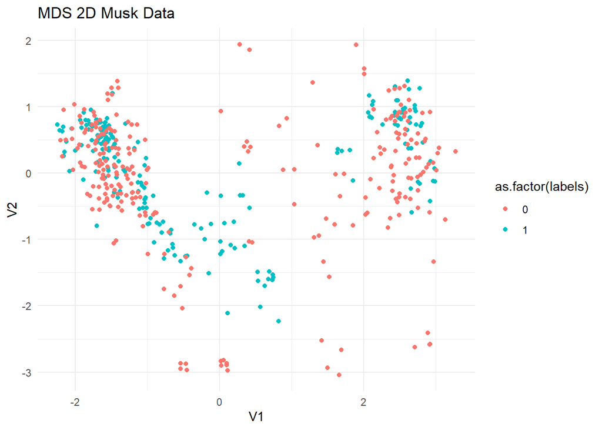

```r
#DISTANCE VISUALIZATION WITH MDS
#for instances (euclidean)

normalize <- function(x, na.rm = TRUE) {
  return((x- min(x)) /(max(x)-min(x)))
}

musk_feature_df=musk_data[,-c(1,2,169)]
musk_normalized=as.data.frame(apply(musk_feature_df, FUN=normalize,MARGIN = 2))

#get euclidean distances (instance level)
instance_distances = dist(x = musk_normalized,method = "euclidean",upper = TRUE)
instance_distances=as.matrix(instance_distances)

#apply mds (to 2d)
mds_musk=cmdscale(instance_distances, k=2, eig=T)
mds_musk_df = as.data.frame(mds_musk$points)
mds_musk_df = cbind(mds_musk_df, index=musk_data$index)
mds_musk_df = cbind(mds_musk_df, labels=musk_data$BagLabel)
#mds_musk$eig


(ggplot(mapping = aes(x=V1 , y=V2),data=(mds_musk_df))+geom_point(aes(col=as.factor(labels)) )
  +labs(title="MDS 2D Musk Data")
  +theme_minimal())
```

#### Visualization with MDS 3D (on instance level)

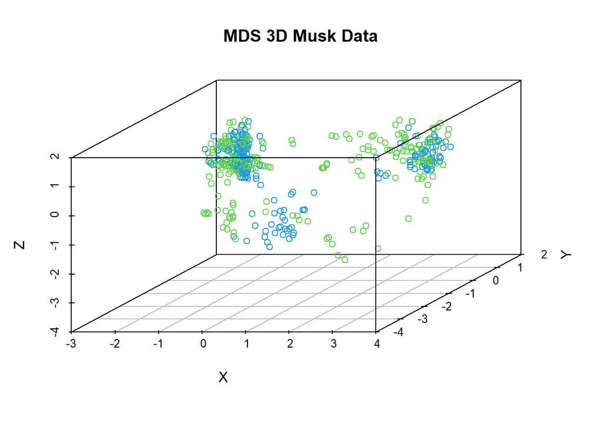

```r
#apply mds (to 3d)
mds_musk_3d=cmdscale(instance_distances, k=3, eig=T)
mds_musk3d_df = as.data.frame(mds_musk_3d$points)
mds_musk3d_df = cbind(mds_musk3d_df, index=musk_data$index)
mds_musk3d_df = cbind(mds_musk3d_df, labels=musk_data$BagLabel)

scatterplot3d(x=mds_musk3d_df$V1, y=mds_musk3d_df$V2, z=mds_musk3d_df$V3,main="MDS 3D Musk Data",
              xlab = "X", ylab= "Y", zlab="Z", color=as.factor((mds_musk3d_df$labels)+3))
```

Not possible to observe clusters visually.

### Representation Approaches for Bags

representation approach 1 = Applying k-means clustering and representing each bag with fraction of instances in each cluster to observe instance frequencies in regions of dataspace.(Şeyma Küçükaşcı & Gökçe Baydoğan, 2018)

representation approach 2 = Representing with mean distance of instances to each cluster. Instance-cluster distance is computed as the average distance between the related instance and observations in that cluster. Bag representation is obtained as the mean of distances to each cluster.

classification approach 1 : NN Classification

classification approach 2 : Random Forest

### K-MEANS parameters

iter.max is set to 25 in Şeyma Küçükaşcı and Gökçe Baydoğan and therefore it is also set to 25 in this work.

nstarts is set to 5 in the original application tuned with a list of 5 and 10 tried in this work.

(16,20,24,30,34,40) will be tried for number of centers.

### NN Classification Parameters

(1,3,5,7,10) will be tried as k.

### Random Forest Classification Parameters

(500,700,800) will be tried as ntree.

### Representation Approach 1

```r
musk_normalized=as.data.frame(apply(musk_feature_df, FUN=normalize,MARGIN = 2))

n_fold=10
nof_rep=1

nofcenters_set = c(16,20,24,30,34,40) #even numbers
nstarts_set = c(5,10)

k_set=c(1,3,5,7,10)
ntree_set=c(500,700,800)

result_nn=vector('list',length(nstarts_set)*length(nofcenters_set)*nof_rep*n_fold*length(k_set))
iter_nn=1

result_rf=vector('list',length(nstarts_set)*length(nofcenters_set)*nof_rep*n_fold*length(ntree_set))
iter_rf=1

for(center in nofcenters_set){
  for (nst in nstarts_set){

    #center=15
    #nst=5

    #kmeans
    set.seed(1234)
    km=kmeans(musk_normalized,centers=center, nstart = nst, iter.max = 25)

    #find nearest clusters for each instance
    nearestCluster=get.knnx(km$centers,musk_normalized,k=1)$nn.index

    #obtain new representation for bags: number of instances in each cluster
    instancelevelClusterAssignments=data.table(BagID=musk_data$BagID,Cluster=array(km$cluster))
    clusterrepr=table(instancelevelClusterAssignments)

    long_repr=data.table(clusterrepr)
    #long_repr=long_repr[order(long_repr[,"BagID"])]

    long_repr=dcast(long_repr,BagID~as.numeric(Cluster), fun.aggregate=sum, value.var ='N')
    long_repr$BagID = as.numeric(long_repr$BagID)
    long_repr=long_repr[order(long_repr$BagID)]

    k=long_repr[,-c("BagID")]
    k= k/bagged_df$nof_instances
    k[,BagID := long_repr$BagID]
    long_repr=k

    long_repr = cbind(long_repr,BagLabel=bagged_df$BagLabel)

    #obtain cv folds 10-fold cv stratified
    labs = long_repr$BagLabel
    n_fold=10
    nof_rep=1
    set.seed(2301)
    cv_indices=generateCVRuns(labs,
                              ntimes =nof_rep,
                              nfold = n_fold,
                              leaveOneOut = FALSE,
                              stratified = TRUE)

    #approach 1: nearest neighbor classification

    #get distance matrix with new representation
    features_dummy = long_repr[,-c("BagID", "BagLabel") ]
    repr_dist = dist(features_dummy,method = "euclidean",upper = TRUE)
    repr_dist = as.matrix(repr_dist)
    diag(repr_dist)=999999


    for(i in 1:nof_rep){
        this_fold=cv_indices[[i]]
        for(j in 1:n_fold){
          test_indices=this_fold[[j]]
          for(k in 1:length(k_set)){

            current_k=k_set[k]
            current_fold=nn_classify_cv(repr_dist,labs,test_indices,k=current_k)

            accuracy=sum(labs[test_indices]==current_fold$prediction$predicted)/length(test_indices)
            tmp=data.table(kmeanscenters=center, startsets=nst ,repid=i,foldid=j,
                           k=current_k,acc=accuracy)
            result_nn[[iter_nn]]=tmp
            iter_nn=iter_nn+1

        }
      }
    }

    ######
    #approach 2 -Random Forest for Classification

    for(i in 1:nof_rep){
      this_fold=cv_indices[[i]]
      for(j in 1:n_fold){
        test_indices=this_fold[[j]]
        for(noftree in 1:length(ntree_set)){

          current_ntree = ntree_set[noftree]

          current_fold= RF_classify_cv(data_df = long_rep,
                                       test_indices = test_indices,
                                       ntr = current_ntree)

          accuracy=sum(labs[test_indices]==current_fold)/length(test_indices)
          tmp=data.table(kmeanscenters=center, startsets=nst ,repid=i,foldid=j,
                         ntree=current_ntree,acc=accuracy)
          result_rf[[iter_rf]]=tmp
          iter_rf=iter_rf+1

        }
      }
    }

    ################

  }
}
```

### NN Classification Results

```r
NN_results_1 = rbindlist(result_nn)
NN_summary_1 = NN_results_1[,list(avg_acc=mean(acc),sdev_acc=sd(acc),result_count=.N),by=list(startsets,kmeanscenters,k)]

#order by avg accuracy
NN_summary_1=NN_summary_1[order(NN_summary_1$avg_acc, decreasing = TRUE)]
head(NN_summary_1,25)
```

```
##     startsets kmeanscenters  k   avg_acc   sdev_acc result_count
##  1:         5            24  1 0.8700000 0.12058954           10
##  2:         5            30  1 0.8477778 0.10658047           10
##  3:        10            30  1 0.8477778 0.10658047           10
##  4:         5            34  1 0.8477778 0.13618856           10
##  5:         5            24  3 0.8366667 0.13699198           10
##  6:         5            30  3 0.8366667 0.13063630           10
##  7:        10            30  3 0.8366667 0.13063630           10
##  8:        10            40  7 0.8244444 0.09278499           10
##  9:        10            34  5 0.8244444 0.16677363           10
## 10:        10            34  1 0.8166667 0.13118119           10
## 11:        10            40  1 0.8166667 0.13509637           10
## 12:         5            30  5 0.8155556 0.14602178           10
## 13:        10            30  5 0.8155556 0.14602178           10
## 14:        10            40 10 0.8155556 0.06972413           10
## 15:        10            34  3 0.8144444 0.12505691           10
## 16:         5            20  1 0.8133333 0.16570091           10
## 17:        10            20  1 0.8133333 0.16570091           10
## 18:         5            30 10 0.8066667 0.14240729           10
## 19:        10            30 10 0.8066667 0.14240729           10
## 20:        10            40  5 0.8055556 0.12230637           10
## 21:         5            16  7 0.8044444 0.15706499           10
## 22:        10            40  3 0.8044444 0.08689113           10
## 23:         5            16  3 0.8033333 0.14325723           10
## 24:         5            24 10 0.7955556 0.14908960           10
## 25:         5            16  5 0.7944444 0.17381778           10
##     startsets kmeanscenters  k   avg_acc   sdev_acc result_count
```

The standard deviations are high, considering the complexity and application time another set of parameters could be preferred.

During the trials it is observed that initial cluster centers (since not specified determined according to the seed) strongly affects the performance of the method.

### Random Forest Results

```r
RF_results_1 = rbindlist(result_rf)
RF_summary_1 = RF_results_1[,list(avg_acc=mean(acc),sdev_acc=sd(acc),result_count=.N),by=list(startsets,kmeanscenters,ntree)]

#order by avg accuracy
RF_summary_1=RF_summary_1[order(RF_summary_1$avg_acc, decreasing = TRUE)]
head(RF_summary_1,10)
```

```
##     startsets kmeanscenters ntree   avg_acc  sdev_acc result_count
##  1:         5            30   500 0.8800000 0.1084623           10
##  2:         5            30   700 0.8800000 0.1084623           10
##  3:         5            30   800 0.8800000 0.1084623           10
##  4:        10            30   500 0.8800000 0.1084623           10
##  5:        10            30   700 0.8800000 0.1084623           10
##  6:        10            30   800 0.8800000 0.1084623           10
##  7:         5            24   500 0.8577778 0.1378654           10
##  8:         5            24   700 0.8477778 0.1459137           10
##  9:         5            24   800 0.8477778 0.1459137           10
## 10:        10            34   700 0.8244444 0.1297671           10
```

Best average accuracy 0.88 is obtained with 30-means centers and 500 trees. Although, average accuracy values with 500, 700 and 800 trees are same 500 trees are preferred to have a simpler model. Trying 5 sets in start is preferred for simplicity.

### Representation Approach 2

```r
#sets same as the first representation
nofcenters_set = c(16,20,24,30,34,40) #even numbers
nstarts_set = c(5,10)

k_set=c(1,3,5,7,10)
ntree_set=c(500,700,800)

result_nn=vector('list',length(nstarts_set)*length(nofcenters_set)*nof_rep*n_fold*length(k_set))
iter_nn=1

result_rf=vector('list',length(nstarts_set)*length(nofcenters_set)*nof_rep*n_fold*length(ntree_set))
iter_rf=1

for(center in nofcenters_set){
  for (nst in nstarts_set){

    #center=15
    #nst=5

    #kmeans
    set.seed(1234)
    km=kmeans(musk_normalized,centers=center, nstart = nst, iter.max = 25)

    #find nearest clusters for each instance
    nearestCluster=get.knnx(km$centers,musk_normalized,k=1)$nn.index

    #obtain new representation for bags:
    #for each instance calculate average distance to each cluster: mean of distances to observations in that cluster
    nearestCluster = data.table(nearestCluster)
    colnames(nearestCluster) = "clusterID"
    nearestCluster[, obs_index := 1:.N]

    newdist = dist(musk_feature_df, method = "euclidean",upper = TRUE)
    newdist = as.matrix(newdist)

    newReprinstance = data.table()


    for(c in 1:center){

      clusterindices = nearestCluster[clusterID == c]$obs_index

      #get distance with all observations in that cluster
      dummy_dist = newdist[,clusterindices]

      #get row means
      newReprinstance = cbind(newReprinstance,rowMeans(dummy_dist))

    }

    #renaming columns
    cnames_list = ((function (x) paste("cluster",x,sep="")) (1:center))
    colnames(newReprinstance) = cnames_list

    newReprinstance[,obs_index := musk_data[,"index"]]
    newReprinstance[,BagID:=musk_data$BagID]
    newReprinstance[,BagLabel:=musk_data$BagLabel]

    #get repr of bags: mean distances of instances to clusters

    newReprbag = data.table()

    for(b in 1:max(unique(musk_data[,"BagID"]))){
      dmmy_df = rbind(colMeans(newReprinstance[BagID==b,-c("obs_index")]))
      newReprbag = rbind(newReprbag,dmmy_df)
    }

    #obtain cv folds 10-fold cv stratified
    labs = newReprbag$BagLabel
    n_fold=10
    nof_rep=1
    set.seed(2301)
    cv_indices=generateCVRuns(labs,
                              ntimes =nof_rep,
                              nfold = n_fold,
                              leaveOneOut = FALSE,
                              stratified = TRUE)

    #approach 1: nearest neighbor classification

    #get distance matrix with new representation
    features_dummy = newReprbag[,-c("BagID", "BagLabel")]
    repr_dist = dist(features_dummy,method = "euclidean",upper = TRUE)
    repr_dist = as.matrix(repr_dist)
    diag(repr_dist)=999999


    for(i in 1:nof_rep){
      this_fold=cv_indices[[i]]
      for(j in 1:n_fold){
        test_indices=this_fold[[j]]
        for(k in 1:length(k_set)){

          current_k=k_set[k]
          current_fold=nn_classify_cv(repr_dist,labs,test_indices,k=current_k)

          accuracy=sum(labs[test_indices]==current_fold$prediction$predicted)/length(test_indices)
          tmp=data.table(kmeanscenters=center, startsets=nst ,repid=i,foldid=j,
                         k=current_k,acc=accuracy)
          result_nn[[iter_nn]]=tmp
          iter_nn=iter_nn+1

        }
      }
    }

    ######
    #approach 2 -Random Forest for Classification

    for(i in 1:nof_rep){
      this_fold=cv_indices[[i]]
      for(j in 1:n_fold){
        test_indices=this_fold[[j]]
        for(noftree in 1:length(ntree_set)){

          current_ntree = ntree_set[noftree]

          current_fold= RF_classify_cv(data_df = newReprbag,
                                       test_indices = test_indices,
                                       ntr = current_ntree)

          accuracy=sum(labs[test_indices]==current_fold)/length(test_indices)
          tmp=data.table(kmeanscenters=center, startsets=nst ,repid=i,foldid=j,
                         ntree=current_ntree,acc=accuracy)
          result_rf[[iter_rf]]=tmp
          iter_rf=iter_rf+1

        }
      }
    }

    ################

  }
}
```

### NN Classification Results

```r
NN_results_2 = rbindlist(result_nn)
NN_summary_2 = NN_results_2[,list(avg_acc=mean(acc),sdev_acc=sd(acc),result_count=.N),by=list(startsets,kmeanscenters,k)]

#order by avg accuracy
NN_summary_2=NN_summary_2[order(NN_summary_2$avg_acc, decreasing = TRUE)]
head(NN_summary_2)
```

```
##    startsets kmeanscenters k   avg_acc  sdev_acc result_count
## 1:         5            30 1 0.8811111 0.1161865           10
## 2:        10            30 1 0.8811111 0.1161865           10
## 3:         5            34 1 0.8800000 0.1204473           10
## 4:         5            40 1 0.8588889 0.1042380           10
## 5:         5            16 1 0.8488889 0.1021309           10
## 6:         5            20 1 0.8477778 0.1361886           10
```

Best average accuracy 0.88 is obtained with 30-means centers and 1-NN classifier.

Considering the high standard deviations algorithm complexity could be taken into account therefore 16-means with 1-NN classifier could be used.

### Random Forest Results

```r
RF_results_2 = rbindlist(result_rf)
RF_summary_2 = RF_results_2[,list(avg_acc=mean(acc),sdev_acc=sd(acc),result_count=.N),by=list(startsets,kmeanscenters,ntree)]

#order by avg accuracy
RF_summary_2=RF_summary_2[order(RF_summary_2$avg_acc, decreasing = TRUE)]
head(RF_summary_2,10)
```

```
##     startsets kmeanscenters ntree   avg_acc  sdev_acc result_count
##  1:         5            16   500 0.8066667 0.1568028           10
##  2:         5            16   700 0.8066667 0.1568028           10
##  3:         5            16   800 0.8066667 0.1568028           10
##  4:        10            16   500 0.8066667 0.1568028           10
##  5:        10            16   700 0.8066667 0.1568028           10
##  6:        10            16   800 0.8066667 0.1568028           10
##  7:         5            20   500 0.8066667 0.1568028           10
##  8:         5            20   700 0.8066667 0.1568028           10
##  9:         5            20   800 0.8066667 0.1568028           10
## 10:        10            20   500 0.8066667 0.1568028           10
```

### References

Şeyma Küçükaşcı, E., & Gökçe Baydoğan, M. (2018). Bag encoding strategies in multiple instance learning problems. Information Sciences, 467, 559–578. https://doi.org/10.1016/j.ins.2018.08.020